# PCIT-CoS-Waitlist RCT Paper 1: Child positivity (NICHD)

Nancy Briggs

06 June 2022

### Child positivity (NICHD)

Output run on 2022-06-10

#### Descriptives

Raw Data

| group | time | n | mean | sd | median | min | max |
| --- | --- | --- | --- | --- | --- | --- | --- |
| 1 | 1 | 28 | 11.054 | 2.932 | 10.5 | 6 | 18 |
| 1 | 2 | 21 | 11.000 | 2.646 | 11.0 | 7 | 16 |
| 1 | 3 | 16 | 12.375 | 3.008 | 13.0 | 7 | 17 |
| 2 | 1 | 28 | 10.595 | 2.901 | 10.0 | 6 | 16 |
| 2 | 2 | 12 | 9.417 | 1.730 | 10.0 | 6 | 12 |
| 2 | 3 | 4 | 14.500 | 1.000 | 15.0 | 13 | 15 |
| 3 | 1 | 27 | 10.700 | 2.827 | 10.0 | 6 | 17 |
| 3 | 2 | 21 | 9.710 | 2.631 | 10.0 | 5 | 16 |
| 3 | 3 | 0 | NaN | NA | NA | Inf | -Inf |

Note:  
One observation in the Waitlist group has data at Follow up. This was set to missing.

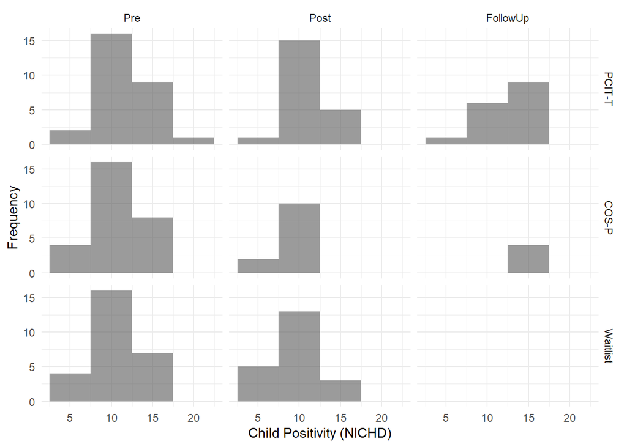

#### Model & Results

A linear mixed model with random effect for individual and fixed effects of group, time and the interaction was run. Estimated marginal means were obtained, and contrasts specified to test Hypothesis 1 and Hypothesis 2.

```
## fixed-effect model matrix is rank deficient so dropping 1 column / coefficient
```

This is the ANOVA table for the model. p-values are likelihood ratio tests for adding the new term to the model just before. A p-value <0.05 indicates that adding that term results in better model fit. The most important p-value is the interaction p-value. Here, there is no evidence that the pattern of change over time is different between the groups (p=0.206).

```
## refitting model(s) with ML (instead of REML)
```

|  | Effect | npar | AIC | BIC | logLik | deviance | Chisq | Df | Pr(>Chisq) |
| --- | --- | --- | --- | --- | --- | --- | --- | --- | --- |
| result0 | Intercept | 3 | 778.882 | 788.050 | -386.441 | 772.882 | NA | NA | NA |
| result1 | Group | 5 | 778.515 | 793.796 | -384.257 | 768.515 | 4.367 | 2 | 0.113 |
| result2 | Time | 7 | 772.206 | 793.600 | -379.103 | 758.206 | 10.308 | 2 | 0.006 |
| result3 | Group*Time | 10 | 773.636 | 804.199 | -376.818 | 753.636 | 4.570 | 3 | 0.206 |

```r
summary(result3)
```

```
## Linear mixed model fit by REML. t-tests use Satterthwaite's method [
## lmerModLmerTest]
## Formula: outcome ~ group * time + (1 | id)
##    Data: dat
##
## REML criterion at convergence: 745.7
##
## Scaled residuals:
##     Min      1Q  Median      3Q     Max
## -1.9729 -0.7357 -0.0164  0.7084  2.5365
##
## Random effects:
##  Groups   Name        Variance Std.Dev.
##  id       (Intercept) 0.04891  0.2212
##  Residual             7.44940  2.7294
## Number of obs: 157, groups:  id, 86
##
## Fixed effects:
##               Estimate Std. Error        df t value Pr(>|t|)
## (Intercept)   11.05395    0.51749 148.99405  21.361   <2e-16 ***
## group2        -0.45800    0.73184 148.99395  -0.626    0.532
## group3        -0.35484    0.73859 148.99363  -0.480    0.632
## time2         -0.05605    0.78837  87.47779  -0.071    0.943
## time3          1.32057    0.85624  99.74268   1.542    0.126
## group2:time2  -1.12033    1.22921 102.06400  -0.911    0.364
## group3:time2  -0.93412    1.11931  86.74742  -0.835    0.406
## group2:time3   2.57862    1.69493 134.45987   1.521    0.131
## ---
## Signif. codes:  0 '***' 0.001 '**' 0.01 '*' 0.05 '.' 0.1 ' ' 1
##
## Correlation of Fixed Effects:
##             (Intr) group2 group3 time2  time3  grp2:2 grp3:2
## group2      -0.707
## group3      -0.701  0.495
## time2       -0.652  0.461  0.457
## time3       -0.601  0.425  0.421  0.395
## group2:tim2  0.418 -0.592 -0.293 -0.641 -0.253
## group3:tim2  0.459 -0.325 -0.656 -0.704 -0.278  0.452
## group2:tim3  0.303 -0.429 -0.213 -0.200 -0.505  0.257  0.141
## fit warnings:
## fixed-effect model matrix is rank deficient so dropping 1 column / coefficient
```

#### Estimated Means & Change

Estimated means for each Treatment and Time are presented. In addition, within-group change between time points is presented with 95% CIs.

##### Group mean difference at each timepoint

Effect sizes all calculated by the pooled T1 SD of the outcome. Adjusted p-value from Bonferroni correction.

Group Differences at Each Time Point

| Group Difference | Time | Mean | SE | t | p | adj p | Lower CL | Upper CL | Effect Size | Lower CL | Upper CL |
| --- | --- | --- | --- | --- | --- | --- | --- | --- | --- | --- | --- |
| 1 - 2 | 1 | 0.458 | 0.732 | 0.625 | 0.806 | 1.000 | -1.276 | 2.192 | 0.157 | -0.390 | 0.715 |
| 1 - 3 | 1 | 0.355 | 0.739 | 0.480 | 0.881 | 1.000 | -1.395 | 2.104 | 0.122 | -0.412 | 0.664 |
| 2 - 3 | 1 | -0.103 | 0.739 | -0.140 | 0.989 | 1.000 | -1.853 | 1.646 | -0.035 | -0.539 | 0.513 |
| 1 - 2 | 2 | 1.578 | 0.997 | 1.583 | 0.256 | 0.347 | -0.782 | 3.939 | 0.541 | -0.129 | 1.308 |
| 1 - 3 | 2 | 1.289 | 0.848 | 1.520 | 0.284 | 0.392 | -0.719 | 3.297 | 0.442 | -0.124 | 1.105 |
| 2 - 3 | 2 | -0.289 | 0.997 | -0.290 | 0.955 | 1.000 | -2.649 | 2.071 | -0.099 | -0.819 | 0.596 |
| 1 - 2 | 3 | -2.121 | 1.552 | -1.367 | 0.361 | 0.522 | -5.794 | 1.553 | -0.727 | -1.942 | 0.406 |
| 1 - 3 | 3 | NA | NA | NA | NA | NA | NA | NA | NA | NA | NA |
| 2 - 3 | 3 | NA | NA | NA | NA | NA | NA | NA | NA | NA | NA |

* Effect size scaled by pooled T1 SD  
† ES 95% Bootstrapped Percentile CI limits  
‡ If you want a positive ES (and it is calculated as negative), be sure to switch the signs and positions of the lower and upper CIs.

##### Change within each group

Within-Group Change and Effect Sizes

| Change | Group | Mean | SE | t | p | adj p | Lower CL | Upper CL | Effect Size | Lower CL | Upper CL |
| --- | --- | --- | --- | --- | --- | --- | --- | --- | --- | --- | --- |
| 1 - 2 | 1 | 0.056 | 0.790 | 0.071 | 0.997 | 1.000 | -1.827 | 1.939 | 0.019 | -0.552 | 0.611 |
| 1 - 3 | 1 | -1.321 | 0.861 | -1.533 | 0.280 | 0.385 | -3.369 | 0.728 | -0.453 | -1.163 | 0.137 |
| 2 - 3 | 1 | -1.377 | 0.910 | -1.512 | 0.290 | 0.402 | -3.545 | 0.792 | -0.472 | -1.170 | 0.163 |
| 1 - 2 | 2 | 1.176 | 0.949 | 1.240 | 0.432 | 0.652 | -1.076 | 3.428 | 0.403 | -0.216 | 1.124 |
| 1 - 3 | 2 | -3.899 | 1.483 | -2.629 | 0.026 | 0.028 | -7.412 | -0.387 | -1.337 | -2.520 | -0.336 |
| 2 - 3 | 2 | -5.076 | 1.598 | -3.176 | 0.005 | 0.006 | -8.864 | -1.287 | -1.740 | -3.029 | -0.654 |
| 1 - 2 | 3 | 0.990 | 0.796 | 1.244 | 0.431 | 0.650 | -0.907 | 2.887 | 0.339 | -0.266 | 0.921 |
| 1 - 3 | 3 | NA | NA | NA | NA | NA | NA | NA | NA | NA | NA |
| 2 - 3 | 3 | NA | NA | NA | NA | NA | NA | NA | NA | NA | NA |

* Effect size scaled by pooled T1 SD  
† ES 95% Bootstrapped Percentile CI limits  
‡ If you want a positive ES (and it is calculated as negative), be sure to switch the signs and positions of the lower and upper CIs.

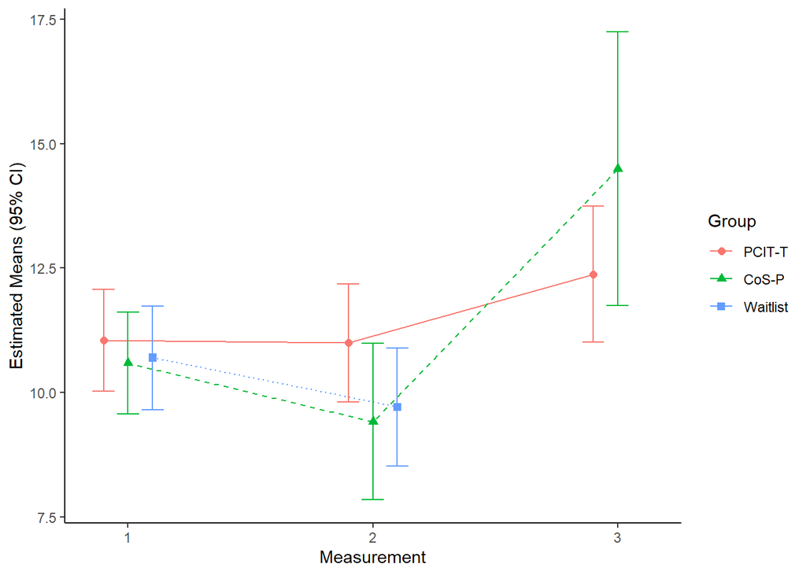

#### Hypothesis 1

We hypothesize that from baseline (‘T1’) to post-treatment/waitlist (‘T2’) there will be a gradient effect, whereby parent-child dyads who receive PCIT-T will show the greatest gains and parent-child dyads who receive no treatment will show the least gains. For the outcome, then, the null hypothesis is:

$H_0: \text {mean change}(\text{PCIT-T}) = \text {mean change}(\text{CoS-P}) = \text {mean change}(\text{Waitlist})$ $H_A: \text {mean change}(\text{PCIT-T}) > \text {mean change}(\text{CoS-P}) > \text {mean change}(\text{Waitlist})$

This is a joint hypothesis test.

First, confirming that the ordering of the means is as hypothesized:

```
## group = 1:
##  contrast estimate    SE    df t.ratio p.value
##  1 - 2       0.056 0.790  91.9   0.071  0.9972
##  1 - 3      -1.321 0.861 103.8  -1.533  0.2797
##  2 - 3      -1.377 0.910  92.2  -1.512  0.2899
##
## group = 2:
##  contrast estimate    SE    df t.ratio p.value
##  1 - 2       1.176 0.949 116.2   1.240  0.4321
##  1 - 3      -3.899 1.483 143.9  -2.629  0.0256
##  2 - 3      -5.076 1.598 131.2  -3.176  0.0053
##
## group = 3:
##  contrast estimate    SE    df t.ratio p.value
##  1 - 2       0.990 0.796  90.5   1.244  0.4307
##  1 - 3      nonEst    NA    NA      NA      NA
##  2 - 3      nonEst    NA    NA      NA      NA
##
## Degrees-of-freedom method: kenward-roger
## P value adjustment: tukey method for comparing a family of 3 estimates
```

scores did not change for the PCITT group from Baseline to post (0.056), and decreased slightly for COSP (1.176).

```
##   (Intercept) group2 group3 time2 time3 group2:time2 group3:time2 group2:time3
## 1           0      0      0     0     0           -1            0            0
## 2           0      0      0     0     1            0            1            0
```

```
##
##   General Linear Hypotheses
##
## Linear Hypotheses:
##        Estimate
## 1 == 0   1.1203
## 2 == 0   0.3865
##
## Global Test:
##        F DF1 DF2 Pr(>F)
## 1 0.5694   2 147 0.5671
```

pvalue>0.05. We do not have evidence that there is a difference in the change over from Baseline to Post amongst the groups.

#### Hypothesis 2

There will be a gradient of size of change from T2 to T3 such that the change in the PCIT-T group > the change in the CoS-P group. This isn’t really a gradient; it’s just 1 hypothesis.

First, the change in PCITT and COSP from time 2 to time 3:

```
## group = 1:
##  contrast estimate    SE    df t.ratio p.value
##  1 - 2       0.056 0.790  91.9   0.071  0.9972
##  1 - 3      -1.321 0.861 103.8  -1.533  0.2797
##  2 - 3      -1.377 0.910  92.2  -1.512  0.2899
##
## group = 2:
##  contrast estimate    SE    df t.ratio p.value
##  1 - 2       1.176 0.949 116.2   1.240  0.4321
##  1 - 3      -3.899 1.483 143.9  -2.629  0.0256
##  2 - 3      -5.076 1.598 131.2  -3.176  0.0053
##
## group = 3:
##  contrast estimate    SE    df t.ratio p.value
##  1 - 2       0.990 0.796  90.5   1.244  0.4307
##  1 - 3      nonEst    NA    NA      NA      NA
##  2 - 3      nonEst    NA    NA      NA      NA
##
## Degrees-of-freedom method: kenward-roger
## P value adjustment: tukey method for comparing a family of 3 estimates
```

```
##
##   Simultaneous Tests for General Linear Hypotheses
##
## Fit: lmer(formula = outcome ~ group * time + (1 | id), data = dat)
##
## Linear Hypotheses:
##        Estimate Std. Error z value Pr(>|z|)
## 1 == 0    3.699      1.821   2.032   0.0422 *
## ---
## Signif. codes:  0 '***' 0.001 '**' 0.01 '*' 0.05 '.' 0.1 ' ' 1
## (Adjusted p values reported -- single-step method)
```

#### Residuals

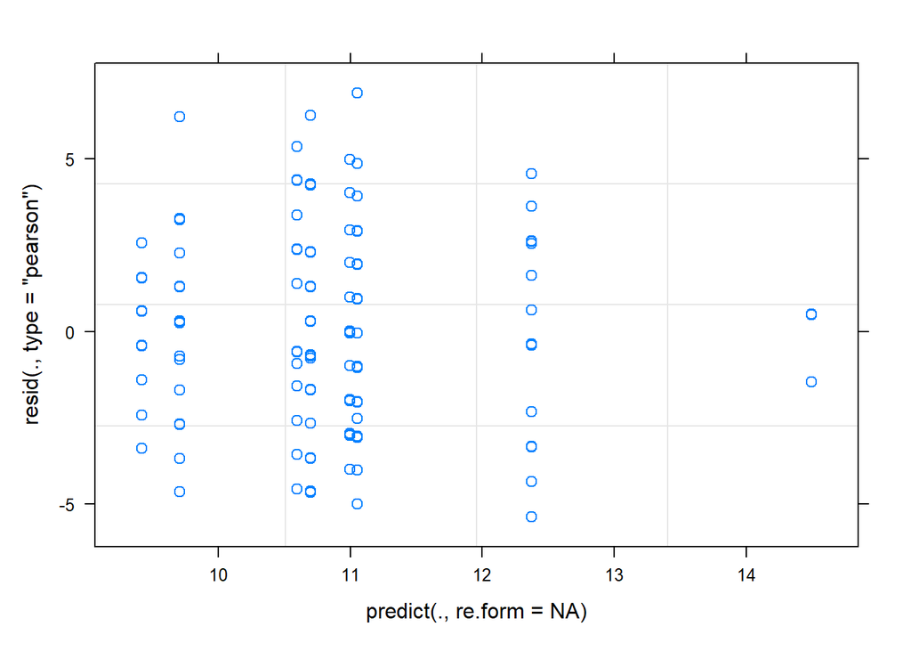

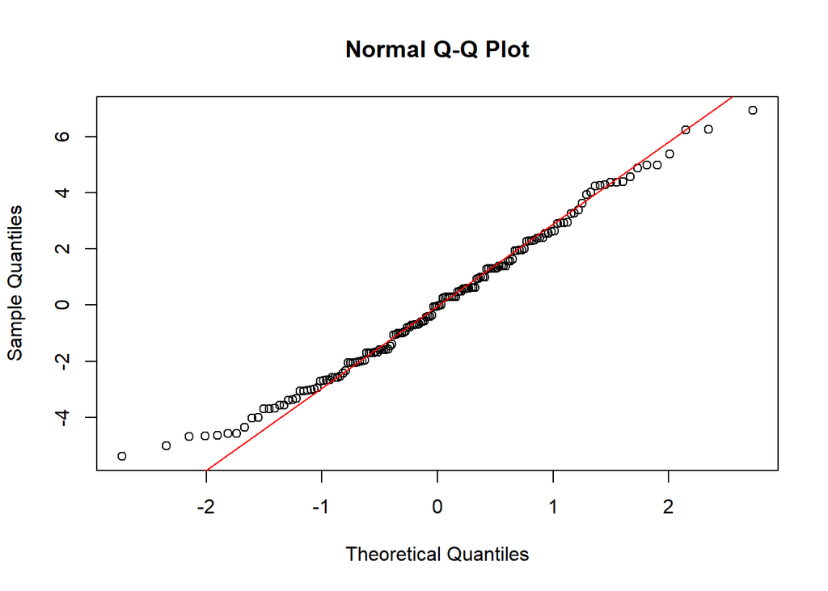

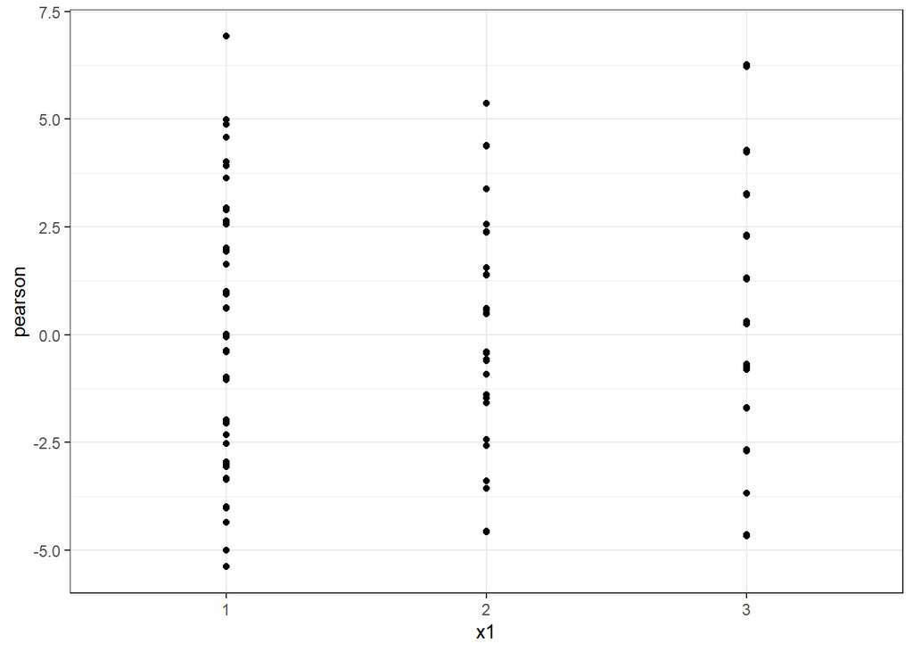

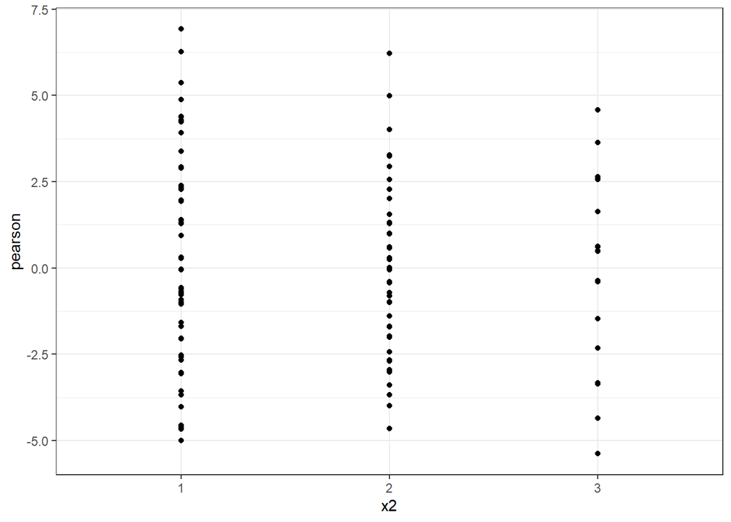

```r
rm(list = ls())
```